# Los Arboles Middle Dashboard Summary

## Report Purpose

This report is created to assist Los Arboles Middle in reflecting on their student groups and how they relate to DA, CSI, and ATSI.

## Qualifying Groups

Differentiated Assistance is determined by the California Dashboard. Colors reflect the latest available status from 2023.

The graphic below shows the color for each student group for each indicator for Monterey Peninsula Unified from the [California Dashboard 2023](https://www.caschooldashboard.org/reports/27660920000000/2023)

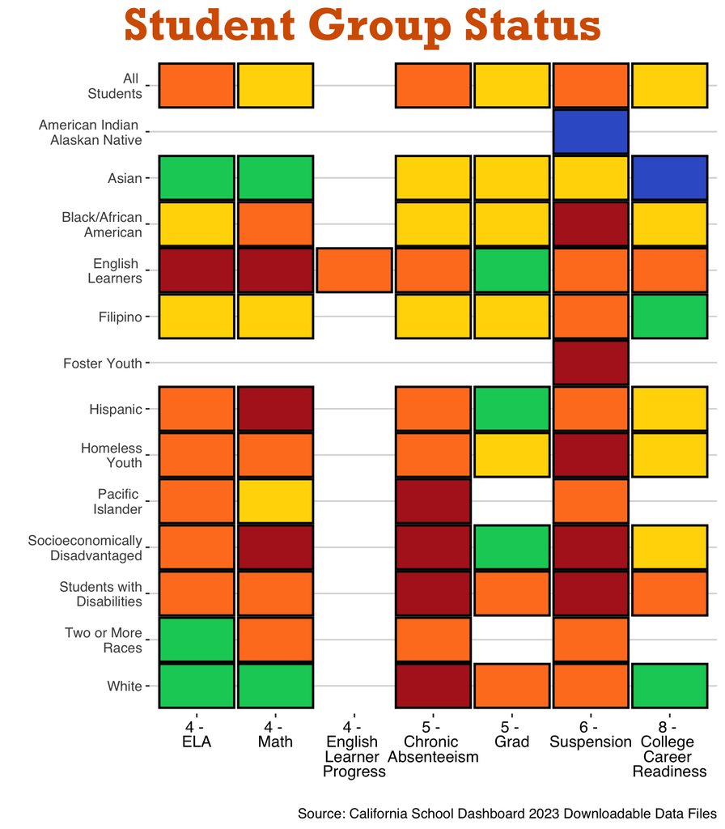

The graphic below shows the color for each student group for each indicator for Los Arboles Middle from the [California Dashboard 2023](https://www.caschooldashboard.org/reports/27660926058713/2023) The school level results contributed to Monterey Peninsula Unified overall.

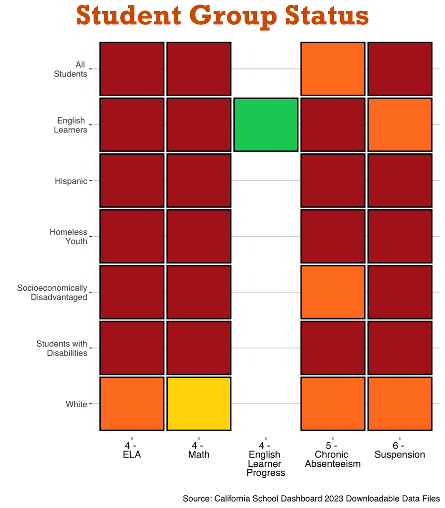

## CSI/ATSI Designations

Under ESSA, schools can be identified for Comprehensive Support and Improvement (CSI) or Additional Targeted Support and Improvement (ATSI). CSI is based on a school’s overall or All Students indicators, whereas ATSI is based on each student group’s indicators. For more information please see: [CDE School Support](https://www.cde.ca.gov/sp/sw/t1/schoolsupport.asp). It is important to note that calculations are only based on student groups with 30 or more students.

Los Arboles Middle is eligible for CSI Low Perform.

## Status Details for all Indicators

These graphs represent all of the indicators from the Dashboard and show how each of the student groups performed.

**Click here to display graphs**

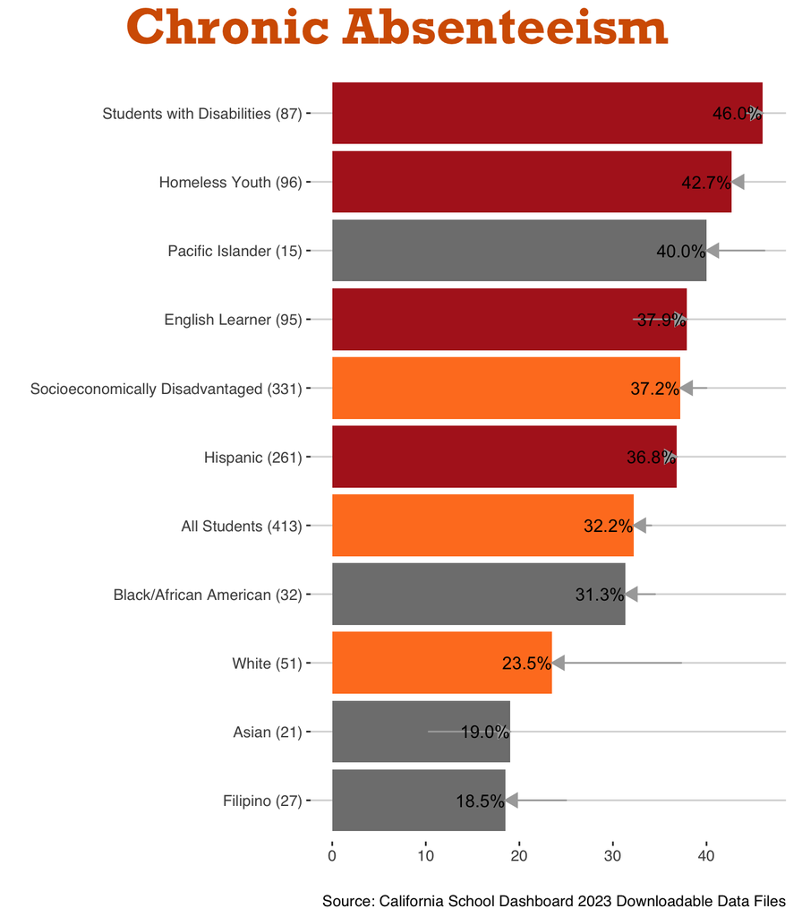

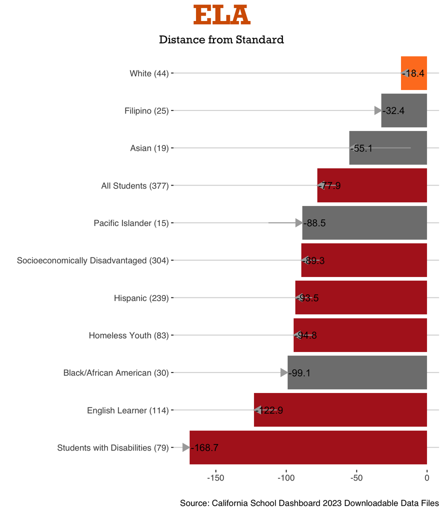

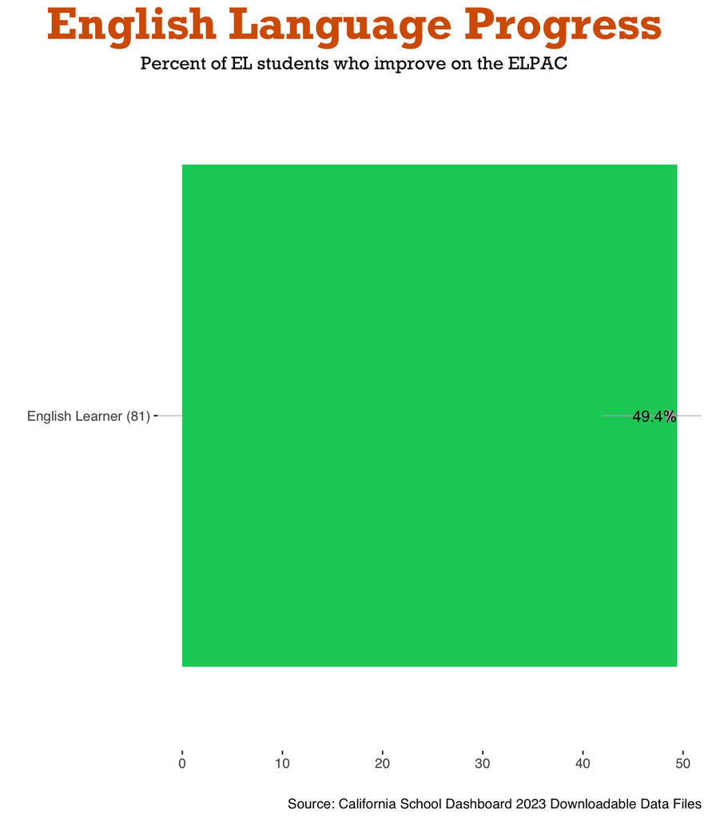

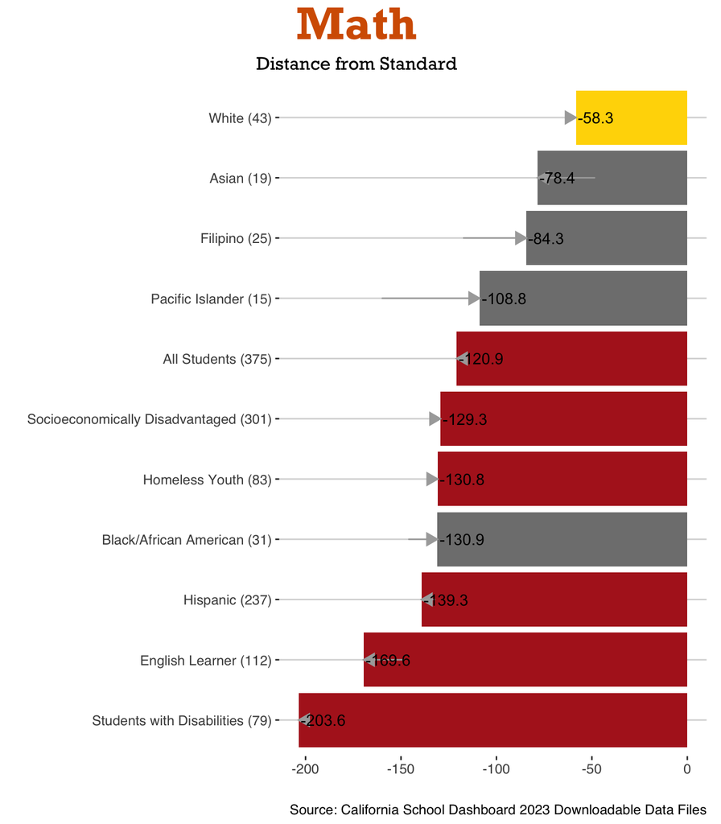

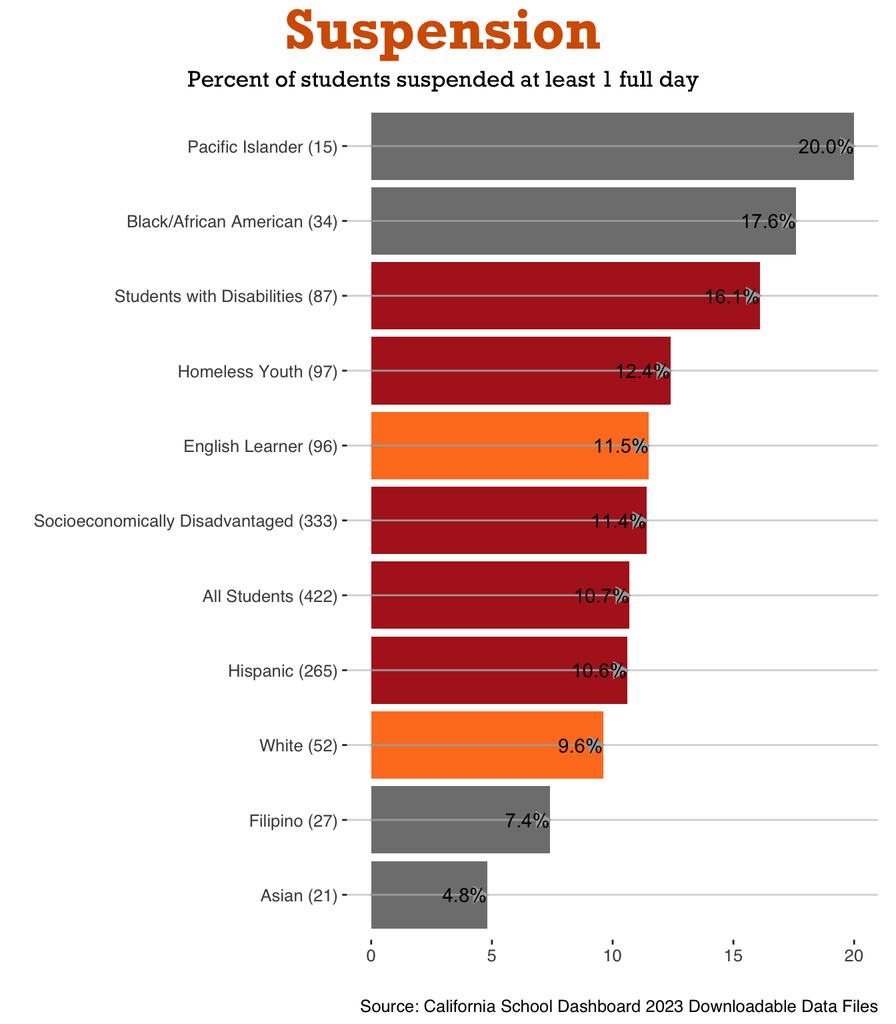

## Historical Graphs for Eligible Groups

These graphs represent all of the indicators from Priority Areas that qualified the district for DA or school for ATSI. They included all DA qualifying student groups and student groups qualify for ATSI on each graph. In addition, the All Students group is included in all graphs for comparisons.

**Click here to display graphs**

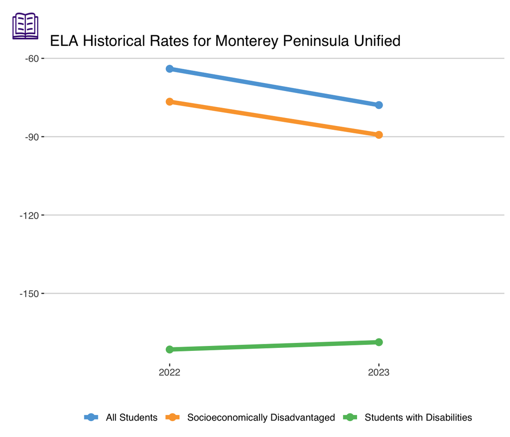

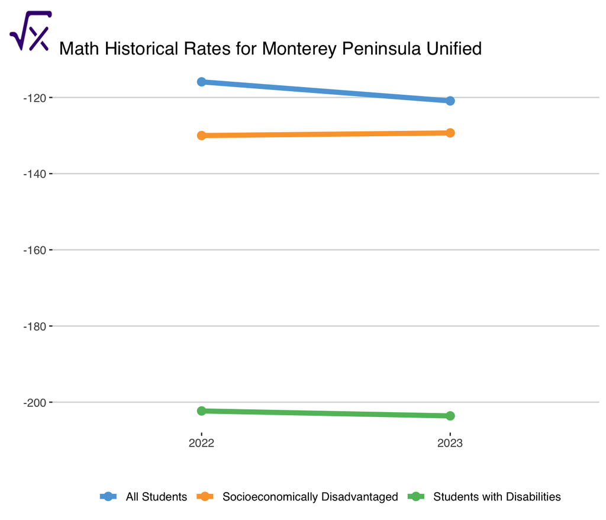

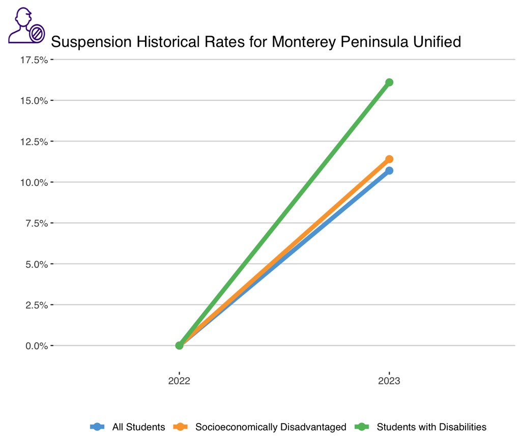

[figure not shown]